# The US Opioid Crisis

Carmel Solomon

March 2026

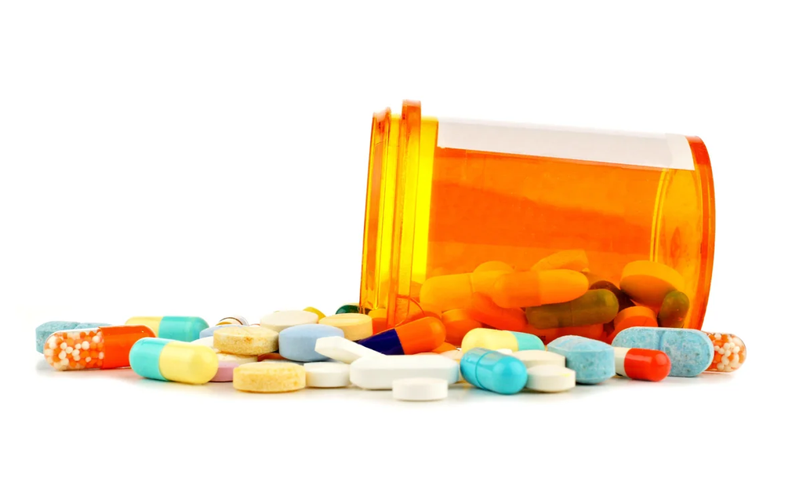

Prescription opioid pills, the starting point of the US opioid crisis.

## Introduction

The United States opioid crisis is one of the most devastating tragedies in modern history. It developed in three waves. The first wave began in the late 1990s when pharmaceutical companies marketed prescription opioid painkillers which lead to widespread overprescribing. The second wave started in 2010 when people who were addicted to prescription opioids switched to cheaper heroin. The third and deadliest wave began around 2013 with the rise of illegally manufactured fentanyl. This increased the drug supply and caused deaths to surge dramatically.

This report uses time series analysis methods to examine the number of opioid overdose deaths in the US each year from 1999 until 2023. The dataset is sourced from the National Institute on Drug Abuse (NIDA), based on data from the CDC WONDER database.

My aim for this analysis is to examine trends over time in deaths related to opioid. I will apply Metas Prophet forecasting model to estimate how these deaths may change in the coming years if historical patterns continue.

## 1 Load and Prepare the Data

The data contains annual opioid overdose death counts from 1999 to 2023, sourced from the National Institute on Drug Abuse (NIDA).

```
##   Year OpioidDeaths
## 1 1999         8048
## 2 2000         8407
## 3 2001         9496
## 4 2002        11920
## 5 2003        12936
## 6 2004        13756
```

The data covers 25 years. Each row represents the year and the corresponding number of opioid overdose deaths, illustrating a clear upward trend over time. The table above displays the first six years of the dataset as a preview.

## 2 Initial Visualisation

Before fitting any model, it is useful to plot the raw data to get a sense of the overall trend.

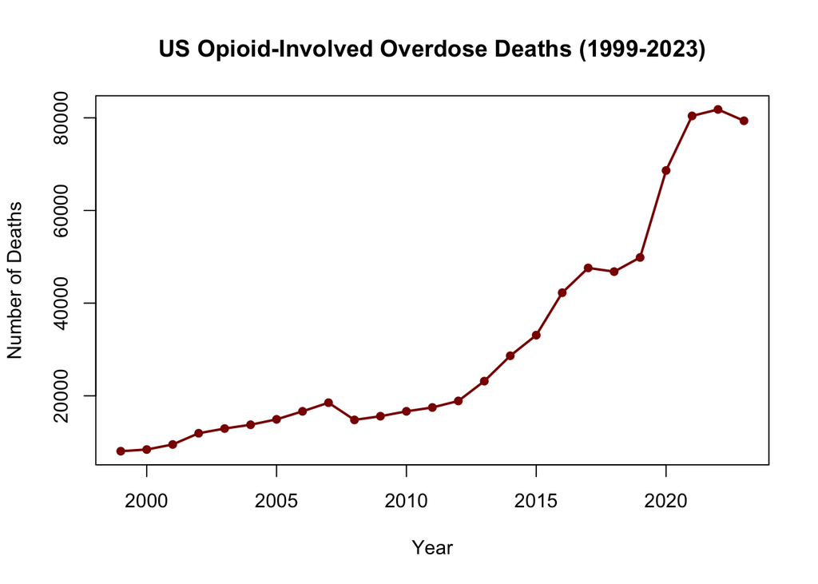

```r
plot(opioidData$Year, opioidData$OpioidDeaths,
     type = "l",
     col = "darkred",
     lwd = 2,
     main = "US Opioid-Involved Overdose Deaths (1999-2023)",
     xlab = "Year",
     ylab = "Number of Deaths")

points(opioidData$Year, opioidData$OpioidDeaths, pch = 16, col = "darkred")
```

The plot reveals a clear upward trend. Deaths remained relatively low through the early 2000s before accelerating from around 2013, coinciding with the rise of illegally manufactured fentanyl. The slight decrease in 2023 suggests the trend is slowing down, although the numbers are still high.

## 3 Exploring Different Time Frames

The opioid crisis occured in three waves. Splitting the data by era reveals how the rate of growth changed over time.

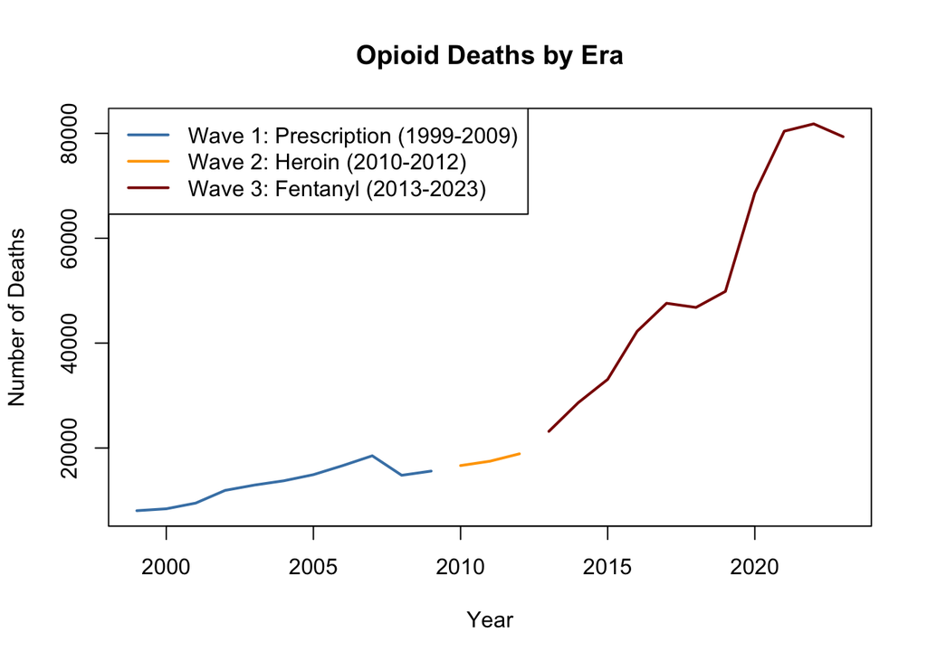

```r
wave1Data <- subset(opioidData, Year <= 2009)
wave2Data <- subset(opioidData, Year >= 2010 & Year <= 2012)
wave3Data <- subset(opioidData, Year >= 2013)

plot(opioidData$Year, opioidData$OpioidDeaths,
     type = "n",
     main = "Opioid Deaths by Era",
     xlab = "Year",
     ylab = "Number of Deaths")

lines(wave1Data$Year, wave1Data$OpioidDeaths, col = "steelblue", lwd = 2)
lines(wave2Data$Year, wave2Data$OpioidDeaths, col = "orange", lwd = 2)
lines(wave3Data$Year, wave3Data$OpioidDeaths, col = "darkred", lwd = 2)

legend("topleft",
       legend = c("Wave 1: Prescription (1999-2009)",
                  "Wave 2: Heroin (2010-2012)",
                  "Wave 3: Fentanyl (2013-2023)"),
       col = c("steelblue", "orange", "darkred"), lwd = 2)
```

```r
cat("Wave 1 average deaths per year:", round(mean(wave1Data$OpioidDeaths), 0), "\n")
```

```
## Wave 1 average deaths per year: 13186
```

```r
cat("Wave 2 average deaths per year:", round(mean(wave2Data$OpioidDeaths), 0), "\n")
```

```
## Wave 2 average deaths per year: 17676
```

```r
cat("Wave 3 average deaths per year:", round(mean(wave3Data$OpioidDeaths), 0), "\n")
```

```
## Wave 3 average deaths per year: 52875
```

The average annual death toll in the fentanyl era is more than four times higher than in the prescription era.

## 4 Exploratory Analysis

### 4.1 Basic Properties

```r
# Convert to a time series object for further analysis
opioidTimeSeries <- ts(opioidData$OpioidDeaths, start = 1999, frequency = 1)

# Check key properties
summary(opioidTimeSeries)
```

```
##    Min. 1st Qu.  Median    Mean 3rd Qu.    Max.
##    8048   14800   18516   31188   46802   81806
```

The data is annual, so there is no seasonal pattern. Deaths increased from 8,048 in 1999 to 81,806 in 2022, showing a large rise over time. The median of 18,516 is much lower than the mean of 31,188, showing the data is skewed upwards by the sharp rise in later years.

### 4.2 Understanding the Growth Trend

A simple linear regression helps estimate the rate of increase in overdose deaths over time.

```r
linearModel <- lm(OpioidDeaths ~ Year, data = opioidData)
summary(linearModel)
```

```
##
## Call:
## lm(formula = OpioidDeaths ~ Year, data = opioidData)
##
## Residuals:
##      Min       1Q   Median       3Q      Max
## -15256.7  -9666.6   -823.5   7928.8  19602.8
##
## Coefficients:
##               Estimate Std. Error t value Pr(>|t|)
## (Intercept) -5925496.4   592086.8  -10.01 7.53e-10 ***
## Year            2962.1      294.4   10.06 6.82e-10 ***
## ---
## Signif. codes:  0 '***' 0.001 '**' 0.01 '*' 0.05 '.' 0.1 ' ' 1
##
## Residual standard error: 10620 on 23 degrees of freedom
## Multiple R-squared:  0.8148, Adjusted R-squared:  0.8068
## F-statistic: 101.2 on 1 and 23 DF,  p-value: 6.821e-10
```

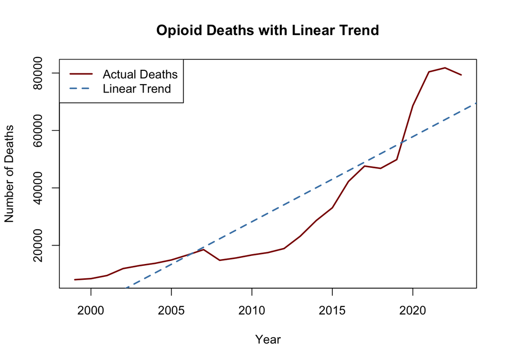

```r
# Overlay the regression line on the plot
plot(opioidData$Year, opioidData$OpioidDeaths,
     type = "l",
     col = "darkred",
     lwd = 2,
     main = "Opioid Deaths with Linear Trend",
     xlab = "Year",
     ylab = "Number of Deaths")

abline(linearModel, col = "steelblue", lwd = 2, lty = 2)
legend("topleft", legend = c("Actual Deaths", "Linear Trend"),
       col = c("darkred", "steelblue"), lty = c(1, 2), lwd = 2)
```

On average, opioid overdose deaths increased by around 2,962 deaths per year over the study period. However, the actual data clearly accelerates beyond the straight line in later years, so a model like Prophet is more suitable.

### 4.3 Autocorrelation Analysis

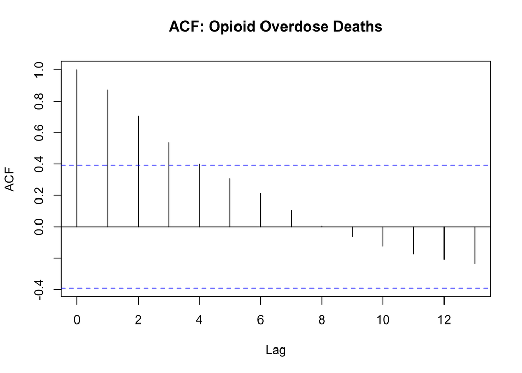

```r
acf(opioidTimeSeries, main = "ACF: Opioid Overdose Deaths")
```

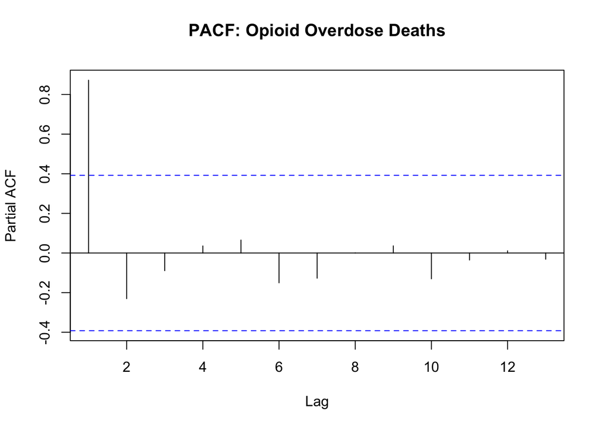

```r
pacf(opioidTimeSeries, main = "PACF: Opioid Overdose Deaths")
```

The ACF shows strong positive correlation, reflecting the upward trend. The PACF has a clear spike at lag 1, suggesting the previous year has the most influence.

## 5 Prophet Forecasting

### 5.1 Preparing Data for Prophet

```r
library(prophet)
# Create Prophet-compatible dataframe
prophetData <- data.frame(
  ds = as.Date(paste0(opioidData$Year, "-01-01")),
  y = opioidData$OpioidDeaths
)

head(prophetData)
```

```
##           ds     y
## 1 1999-01-01  8048
## 2 2000-01-01  8407
## 3 2001-01-01  9496
## 4 2002-01-01 11920
## 5 2003-01-01 12936
## 6 2004-01-01 13756
```

Metas Prophet requires data with a date column named `ds` and a value column named `y`. Since our data is annual, dates are set to the 1st of January of each year.

### 5.2 Fitting the Prophet Model

```r
prophetModel <- prophet(
  prophetData,
  yearly.seasonality = FALSE,
  weekly.seasonality = FALSE,
  daily.seasonality = FALSE
)
```

```
## n.changepoints greater than number of observations. Using 19
```

Prophet models time series data using the following formula:

$$y(t) = g(t) + s(t) + h(t) +
\epsilon_t$$
Where g(t) is the trend, s(t) is seasonality, h(t) is holiday effects and ϵt is the error. Since our data is annual, seasonality and holidays are set to zero, so the model focuses entirely on the trend component g(t).

### 5.3 Forecasting Future Values

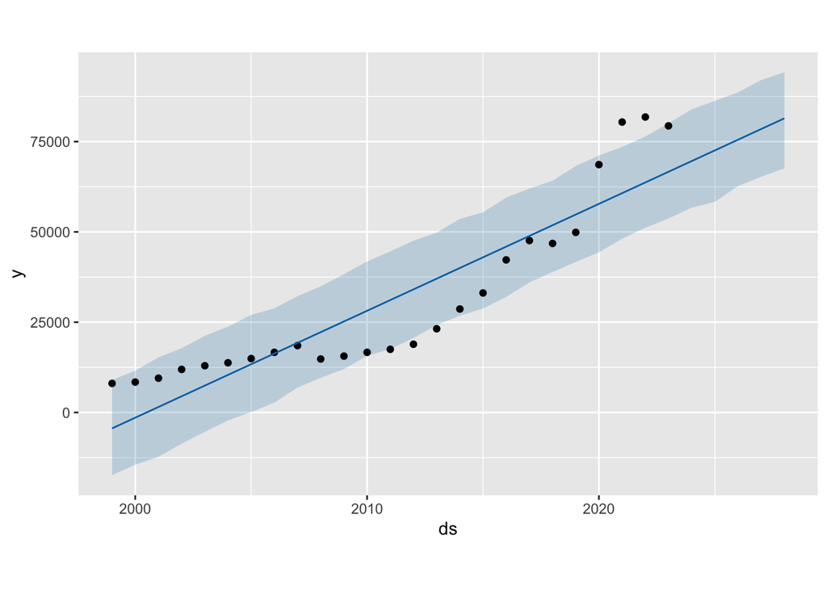

```r
futureDates <- make_future_dataframe(prophetModel, periods = 5, freq = "year")
opioidForecast <- predict(prophetModel, futureDates)

plot(prophetModel, opioidForecast)
```

### 5.4 Prophet Trend Component

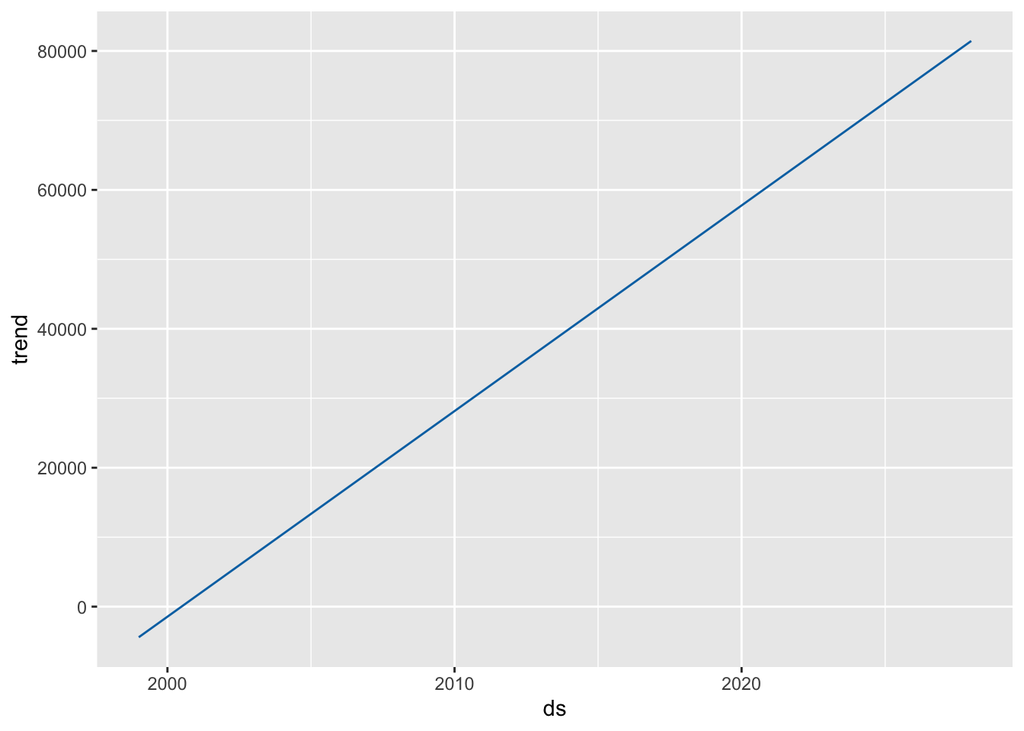

```r
prophet_plot_components(prophetModel, opioidForecast)
```

### 5.5 Forecast Table

```r
forecastTable <- opioidForecast[
  (nrow(opioidForecast)-5+1):nrow(opioidForecast),
  c("ds", "yhat", "yhat_lower", "yhat_upper")
]

forecastTable$ds <- format(forecastTable$ds, "%Y")
colnames(forecastTable) <- c("Year", "Predicted Deaths", "Lower Bound", "Upper Bound")

forecastTable
```

```
##    Year Predicted Deaths Lower Bound Upper Bound
## 26 2024         69600.26    56694.90    83916.97
## 27 2025         72566.88    58321.90    86284.30
## 28 2026         75525.39    62687.39    88641.54
## 29 2027         78483.90    65269.28    92049.44
## 30 2028         81442.41    67570.14    94206.69
```

## Conclusion

This analysis used Meta’s Prophet model to examine trends in opioid overdose deaths in the United States between 1999 and 2023. The time series shows a strong upward trend, with a noticeable acceleration in recent years linked to the rise of synthetic opioids such as fentanyl.

*Data source: National Institute on Drug Abuse (NIDA), sourced from CDC WONDER. Available at: https://nida.nih.gov/research-topics/trends-statistics/overdose-death-rates*